# Анализ lifetime клиента (дожития)

## Что такое анализ дожития?

Название взято из медицины, т.к. суть анализа заключается в изучении продолжительности жизни пациента после приема препарата или других факторов влияния на здоровье. Поэтому и называется он - анализ дожития (survival analysis).

В нашем случае анализ может быть применем для оценки lifetime пользователей в продукте. Метод часто применяется для расчета LTV на конкретный день использования сервиса. Также широкую практику анализ приобрел в HR-практике в средних-крупных компаниях, чтобы предсказывать время пребывания в компании еще на этапе отсмотра CV кандидата.

*Анализ помогает ответить на вопрос: Как долго пользователь “живет” в сервисе/продукте?*

## Загрузка данных и их описание

Взглянем на данные

```r
df_surv <- read.table("https://raw.githubusercontent.com/aboutisya/r_surv/master/df_surv.csv",
                       row.names = 1,
                       sep= ";",
                       header=T)
head(df_surv)
```

|  | uid | group | time | churned |
| --- | --- | --- | --- | --- |
| 1 | 10001 | A | 211 | 1 |
| 4 | 10002 | A | 73 | 1 |
| 5 | 10003 | A | 73 | 1 |
| 6 | 10004 | B | 150 | 0 |
| 7 | 10005 | A | 160 | 1 |
| 8 | 10006 | B | 543 | 0 |

Представим, что мы анализируем отток пользователей:

- uid - уникальный id пользователя
- group - группа, к которой относится пользователь
- time - время дожития от начала регистрации в сервисе в днях
- churned - факт оттока. Обратите внимание, что 0 говорит о наличии активности на time-день, а 1 об уходе из сервиса (допустим, не было следующей оплаты)

Некоторое описание данных:

```r
str(df_surv)
```

```
'data.frame':   178 obs. of  4 variables:
 $ uid    : int  10001 10002 10003 10004 10005 10006 10007 10008 10009 10010 ...
 $ group  : Factor w/ 2 levels "A","B": 1 1 1 2 1 2 1 1 1 1 ...
 $ time   : int  211 73 73 150 160 543 485 718 130 233 ...
 $ churned: int  1 1 1 0 1 0 1 1 1 0 ...
```

```r
# доли ушедших и оставшихся по группам
table(df_surv$churned,df_surv$group)
```

```
     A  B
  0 26 48
  1 54 50
```

## Анализ дожития

#### Анализ без факторов

Для анализа дожития используется регрессия с двумя зависимыми переменными: время и событие. Для своего анализа мы будем использовать процедуру Каплана-Мейера (Kaplan-Meier estimator). В R это делается достаточно просто:

```r
fit_km <- survfit(Surv(time, churned) ~ 1, data = df_surv)
fit_km
```

```
Call: survfit(formula = Surv(time, churned) ~ 1, data = df_surv)

      n  events  median 0.95LCL 0.95UCL
    178     104     318     257     500
```

~1 в формуле означает, что мы считаем модель без факторов. Такая модель позволит посмотреть на общую картину оттока. В результате мы видим медианный день пребывания на сервисе и 95%ДИ для нее. Но медиана здесь рассчитывалась иначе, чем если бы мы просто применили `median()`. В данном случае, 318 – день для 0.5 вероятности дожития.

Чтобы проще было понимать, о чем речь, давайте взглянем на график:

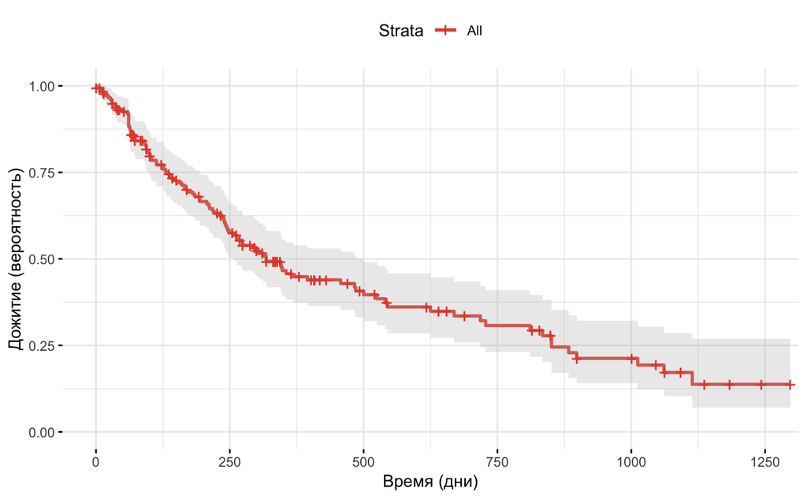

График хорошо показывает, как с течение времени падает вероятность дожить на до конкретного дня.

```r
dat_km <- fortify(fit_km)
head(dat_km)
```

|  | time | n.risk | n.event | n.censor | surv | std.err | upper | lower |
| --- | --- | --- | --- | --- | --- | --- | --- | --- |
| 1 | 1 | 178 | 1 | 1 | 0.9943820 | 0.005633825 | 1.0000000 | 0.9834624 |
| 2 | 7 | 176 | 0 | 1 | 0.9943820 | 0.005633825 | 1.0000000 | 0.9834624 |
| 3 | 9 | 175 | 1 | 0 | 0.9886998 | 0.008036212 | 1.0000000 | 0.9732491 |
| 4 | 11 | 174 | 1 | 0 | 0.9830177 | 0.009889443 | 1.0000000 | 0.9641473 |
| 5 | 14 | 173 | 0 | 1 | 0.9830177 | 0.009889443 | 1.0000000 | 0.9641473 |
| 6 | 15 | 172 | 1 | 1 | 0.9773024 | 0.011480454 | 0.9995423 | 0.9555574 |

Чтобы было нагляднее основные точки отсечения модели, выделим пунктирными линиями 25, 50 и 75 квантили

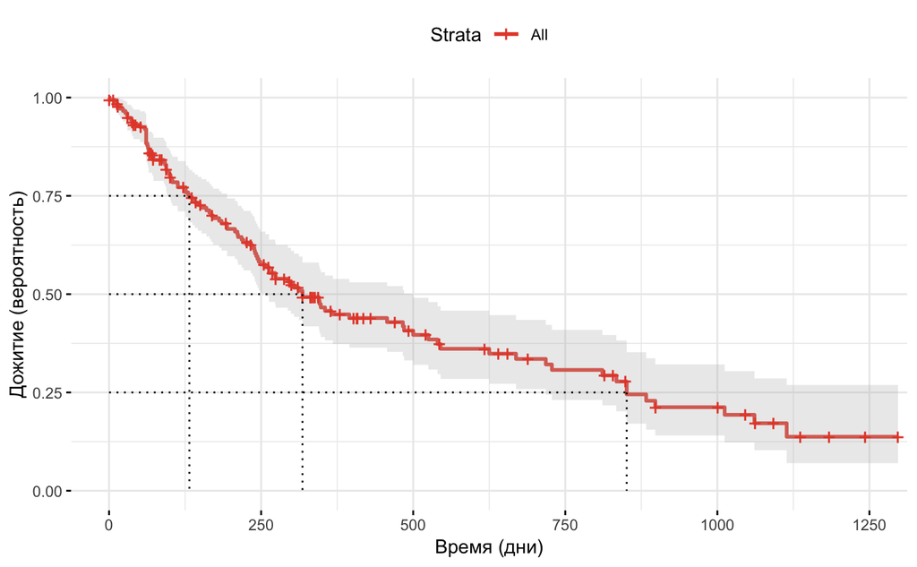

```r
mc <- data.frame(q = c(.25, .5, .75),
                  km = quantile(fit_km))
ggsurvplot(fit_km ,main = "Вероятность дожития сотрудников",
           xlab = "Время (дни)",
           ylab = "Дожитие (вероятность)",
           palette = "npg",
           censor = T,
           conf.int = T,
           risk.table = T,
           ggtheme = theme_minimal())$plot +
  geom_segment(data = mc, aes(x = km.quantile, y = 1-q, xend = km.quantile, yend = 0), lty = 3) +
  geom_segment(data = mc, aes(x = 0, y = 1-q, xend = km.quantile, yend = 1-q), lty = 3)
```

Выведем результат

```r
mc
```

|  | q | km.quantile | km.lower | km.upper |
| --- | --- | --- | --- | --- |
| 25 | 0.25 | 132 | 99 | 194 |
| 50 | 0.50 | 318 | 257 | 500 |
| 75 | 0.75 | 851 | 718 | NA |

25% ушедших в пределах 132 дней. Можно обратить внимание на отрезок между 50 и 75 квантилей, он достаточно затяжной – 533 дня против 132.

#### Анализ факторов

Мы можем объяснять зависимость дожития с помощью вспомогательных переменных. Для этого вместо единички в формуле подставим необходимый фактор:

```r
fit_km_w_fct <- survfit(Surv(time, churned) ~ group, data = df_surv)
fit_km_w_fct
```

```
Call: survfit(formula = Surv(time, churned) ~ group, data = df_surv)

         n events median 0.95LCL 0.95UCL
group=A 80     54    263     212     395
group=B 98     50    483     274     851
```

Группа В кажется живет дольше, но по ДИ95 уже видно, что значимой разницы между ними нет. Построим график:

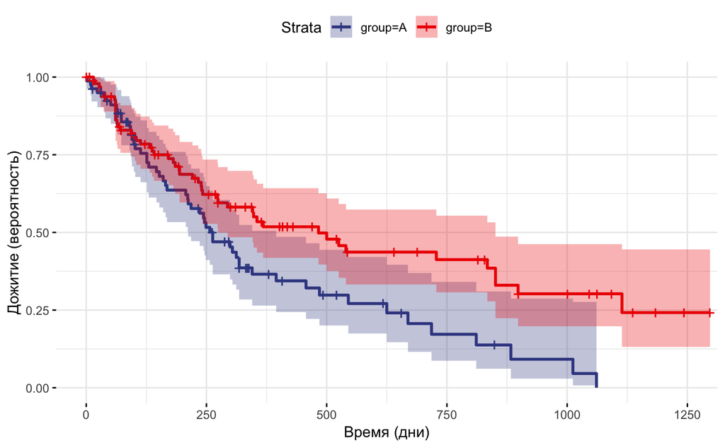

```r
ggsurvplot(fit_km_w_fct,
           risk.table = T,
           palette = "aaas",
           xlab = "Время (дни)",
           ylab = "Дожитие (вероятность)",
           censor = T,
           conf.int = T,
           ggtheme = theme_minimal())$plot
```

## Выводы

Анализ выживаемости или анализ дожития (survival analysis) является полезным инструментом в задачах прогноза пребывания пользователя в сервисе. Также стоит отметить, что существует возможность объяснять этот прогноз с помощью дополнительных переменных, как мы увидели это в разбивке по группам А и В.